# Frequently Asked Questions

ssdtools Team

2026-08-31

### How can I plot the model averaged fit and the individual fits?

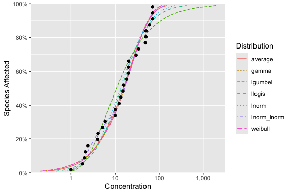

```r
library(ssdtools)

dist <- ssd_fit_dists(ssddata::ccme_boron)
ssd_plot_cdf(dist, average = NA)
```

### How can I include mathematical expressions in the x-axis label when using `ssd_plot()`?

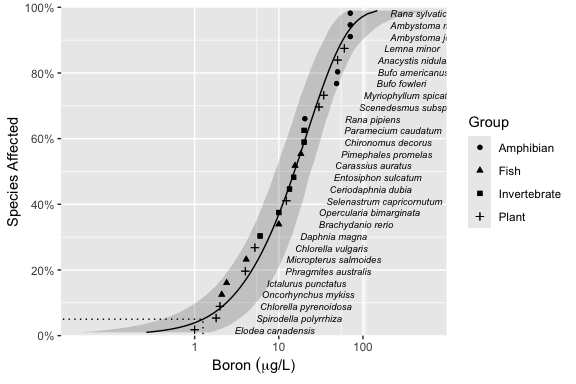

```r
library(ssdtools)

ssd_plot(ssddata::ccme_boron, ssdtools::boron_pred, label = "Species", shape = "Group") +
  ggplot2::scale_x_continuous(latex2exp::TeX("Boron $(\\mu g$/L)$"), breaks = c(1, 10, 100, 1000, 10000))
```

## Licensing

Copyright 2015-2023 Province of British Columbia  
Copyright 2021 Environment and Climate Change Canada  
Copyright 2023-2025 Australian Government Department of Climate Change, Energy, the Environment and Water

The documentation is released under the [CC BY 4.0 License](https://creativecommons.org/licenses/by/4.0/)

The code is released under the [Apache License 2.0](https://www.apache.org/licenses/LICENSE-2.0)

## Censoring

### What is censored data?

Data is censored when the exact value is uncertain. There are three primary types of censoring. Right censoring when only the lower bound is known (>), left censoring when only the upper bound is known (<) and interval censored when both the lower and upper bound are known (><). Uncensored data can be thought of as interval censored data in which the upper and lower bound are identical (=). Likewise, missing data can be considered to be censored data in which both the upper and lower bound are unknown (?).

### How is censored data coded in ssdtools?

Censored data is coded by specifying the lower bound values in one column (>) and the upper bound values in a second column (<). Unknown lower bounds are coded using NA or 0 while unknown upper bounds are coded using NA or Inf. The name of the columns with the lower and upper bound values are then passed to the `left` (>) and `right` (<) arguments in the `ssd_fit_dists()` function, respectively.

### What are the current limitations on analyzing censored data?

Currently `ssdtools` has the following limitations on the analysis of censored data:

- model averaging when the distributions have the same number of parameters only; and
- estimation of confidence interval using non-parametric bootstrapping only.